# Lab_01_working_draft

Robert Alward

2/13/2021

## Project Overview

In this project I am looking to provide an answers to the question, “How do the final grades of those who who study a lot differ from those who don’t study a lot, and are there actions that change the differences created by study time.” In this document I will

- load and clean the two key datasets math and Portuguese final grades and life effects
- separate data sets into difference subsets depending on different factors
- Key factors to separate on: absences, alcohol consumption, going out, romantic, freetime, romantic relationships, extra-curricular activities
- Prepare different graphs based on the factors above, study time, and final grades
- report the results
- give several possible conclusions based on the results

## Data

To address this question, I will use data from the 2014 UCI Dataset on Student Performance, which was conducted in Portugal to looks at “student achievement in secondary education of two Portuguese schools”. More information about this survey can be found at [UCI’s Machine Learning Repository Page] (https://archive.ics.uci.edu/ml/datasets/Student+Performance).

Here there are 5 different datasets described below:

- mat: This is the original dataset of final math scores and recorded factors
- por: This is the original dataset of the final portugese scores and recorded factors
- combo: This is the combined full datasets of math and portugese scores
- mat_small: This is the dataset containing the factors for the analysis on the math dataset
- por_small: This is the dataset containing the facotrs for analysis on the portugese dataset

## Trial Plots

Here I am looking at the trial aggregate plots for the datasets as well as the mean of performances

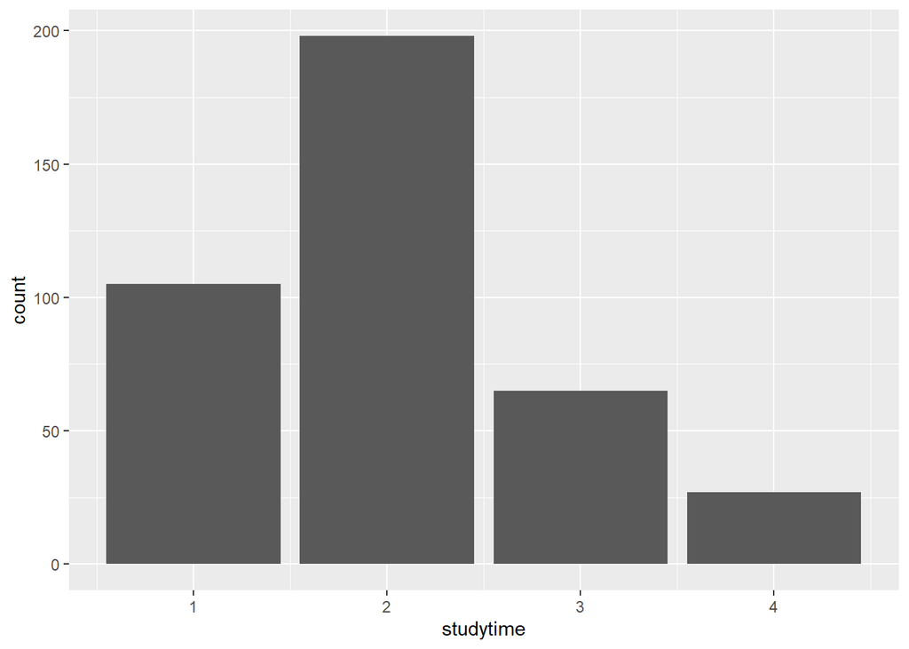

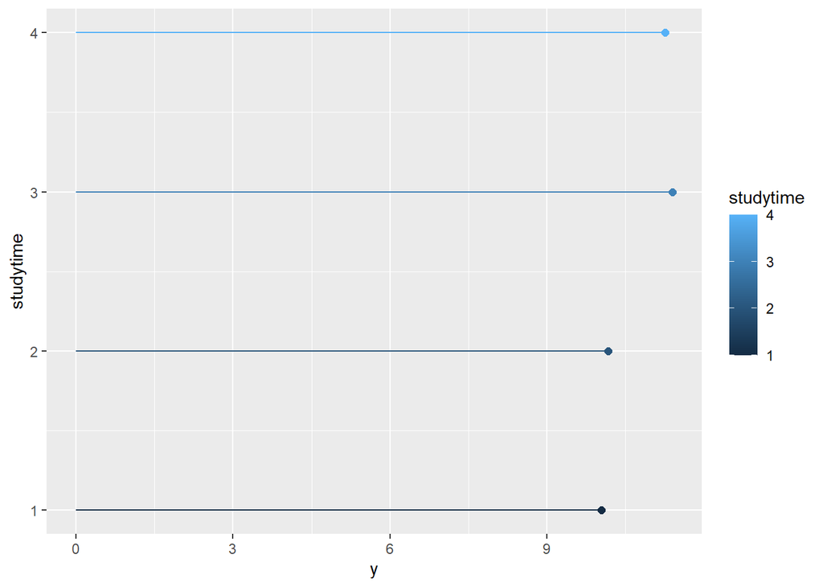

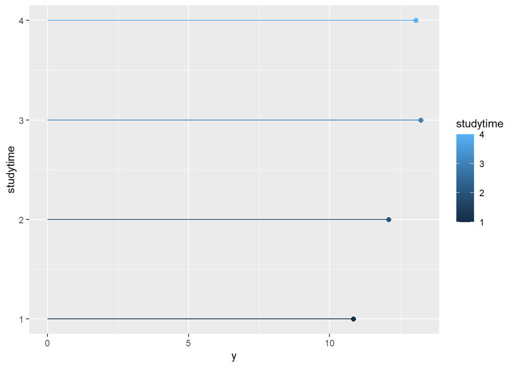

## Initial Graph Creation

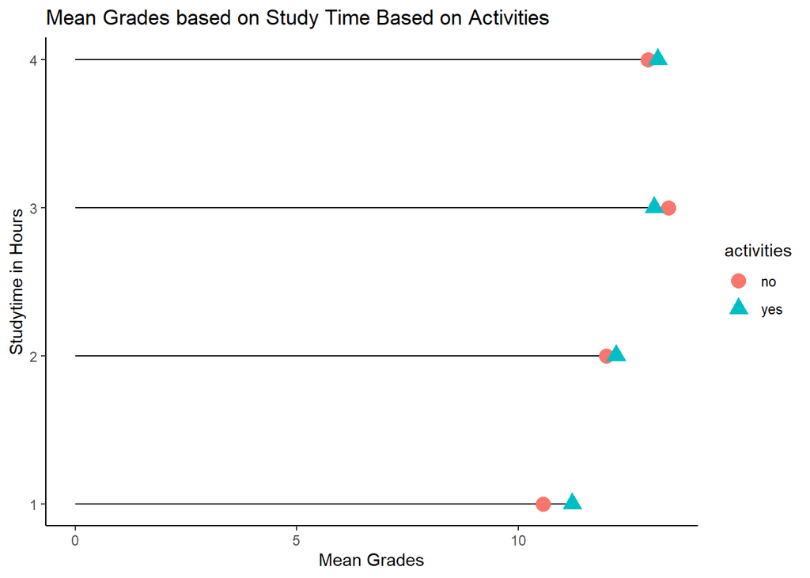

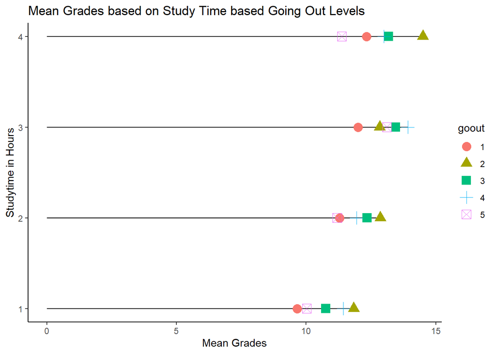

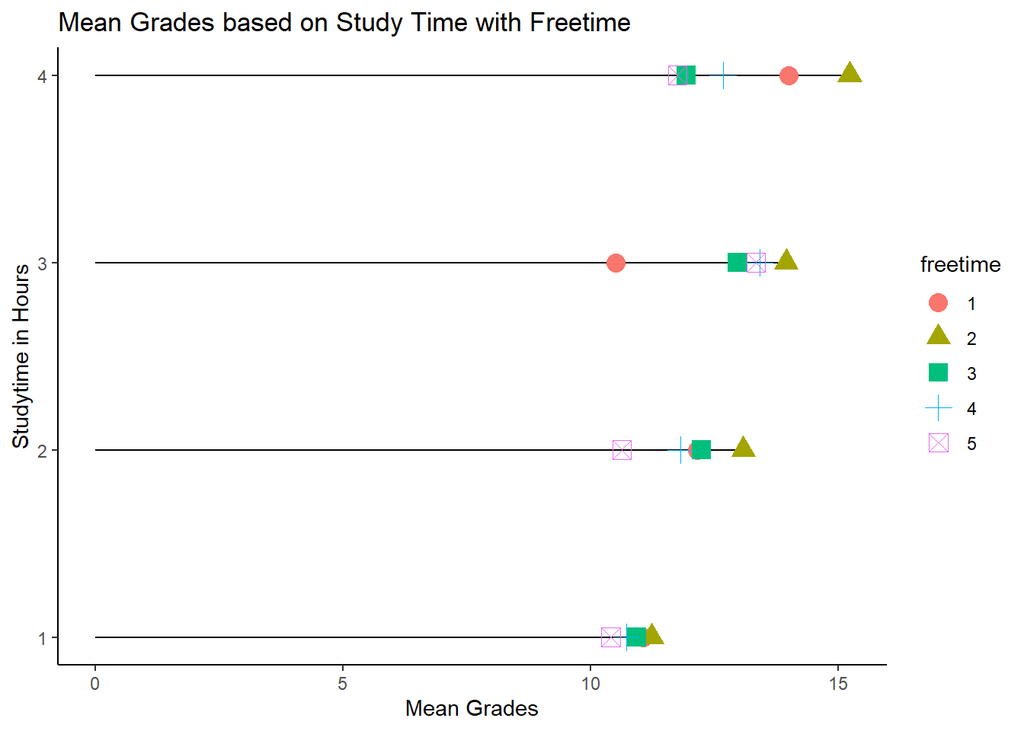

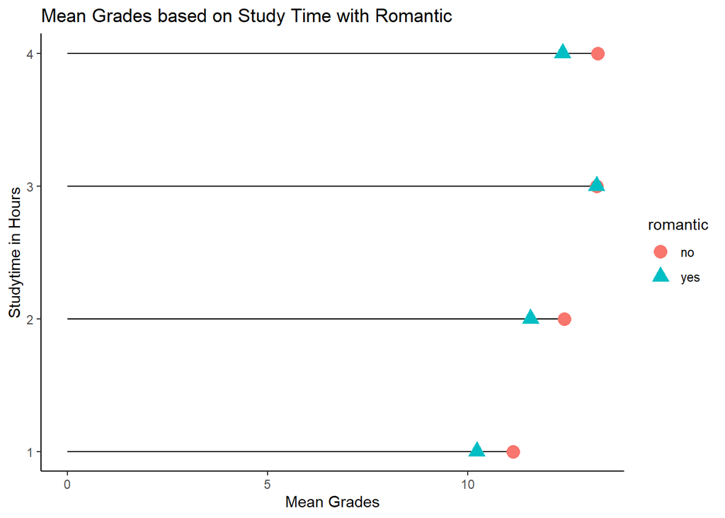

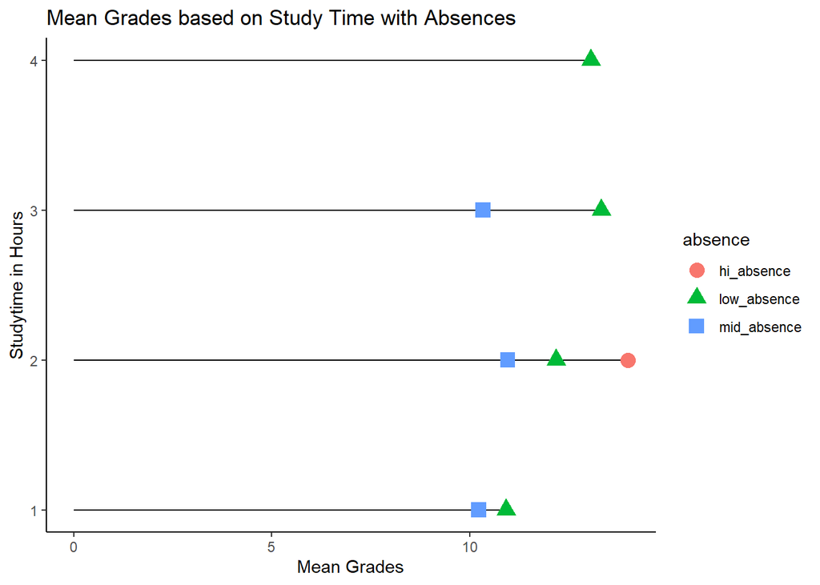

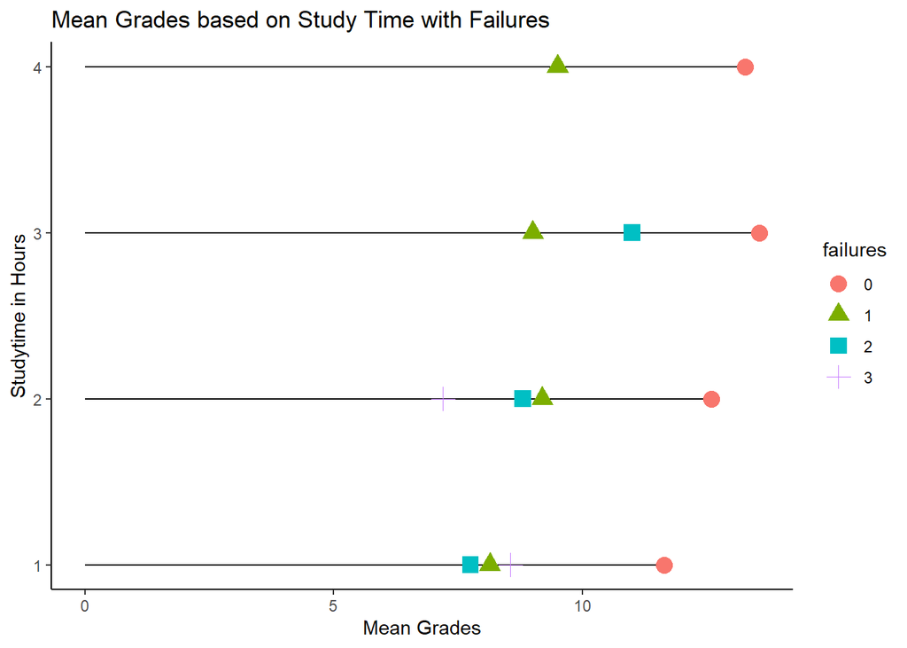

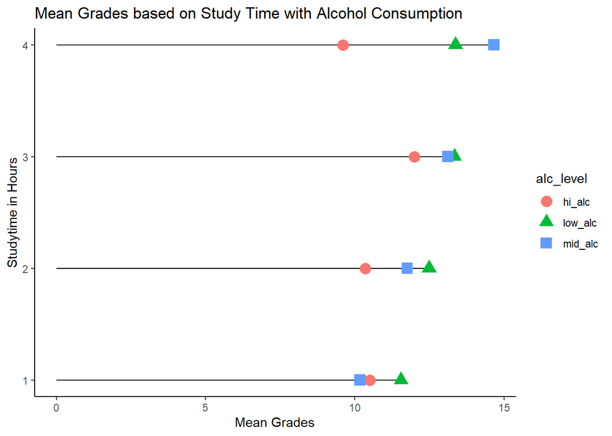

## Selected Graphs for Final Analysis

[figure not shown]

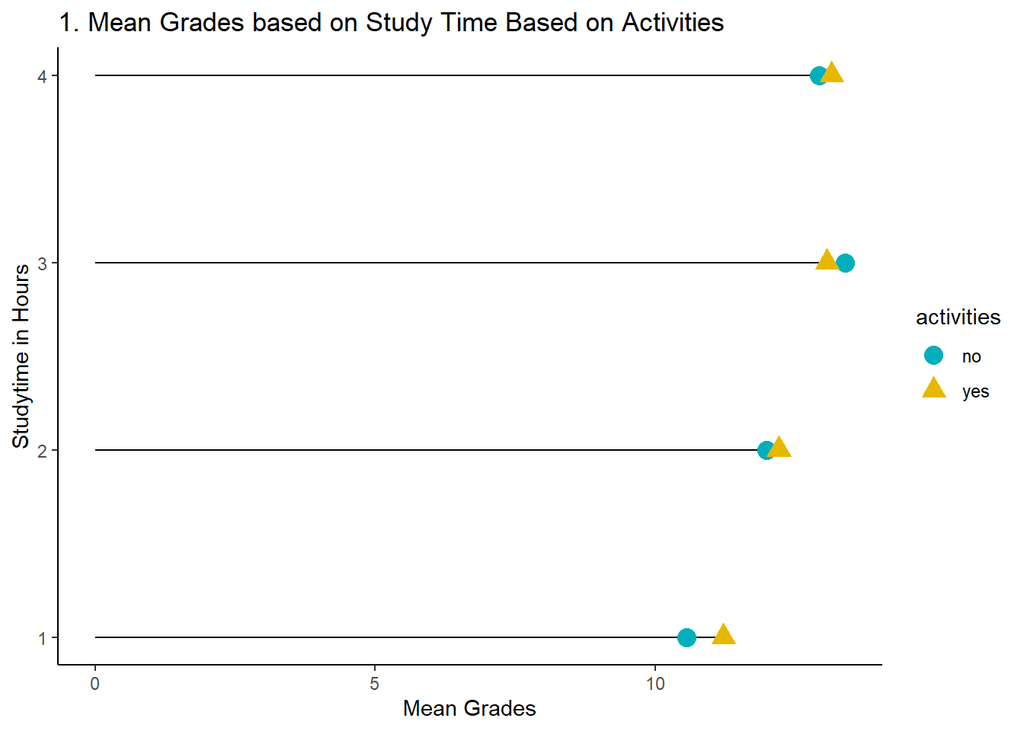

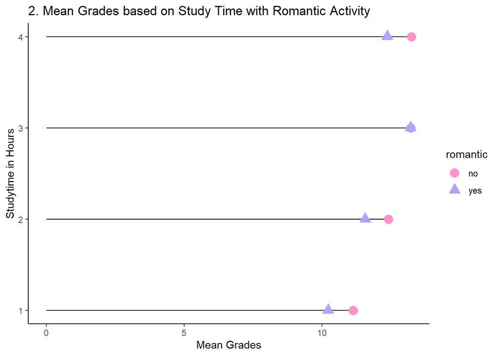

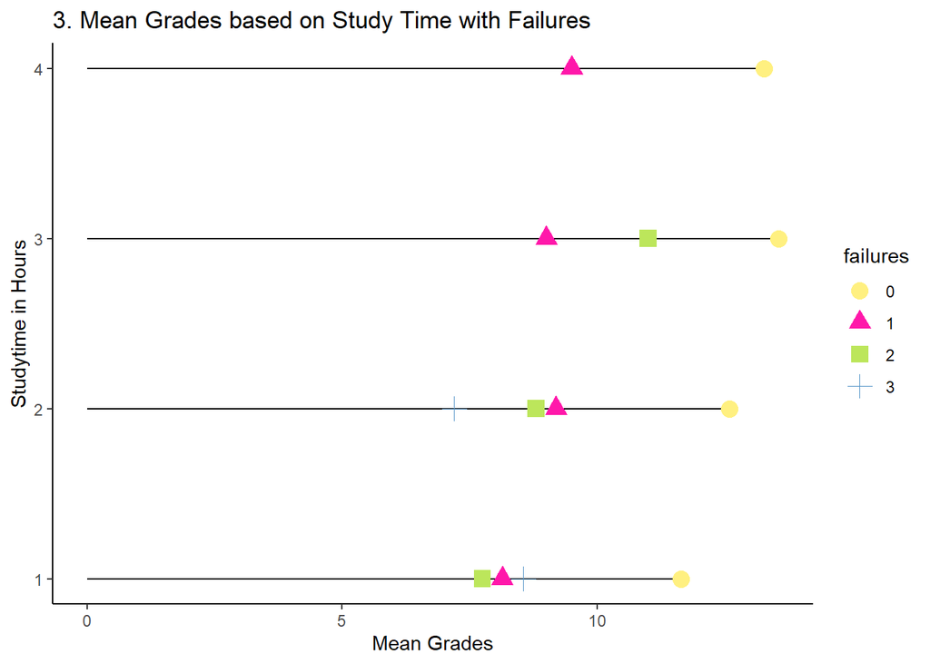

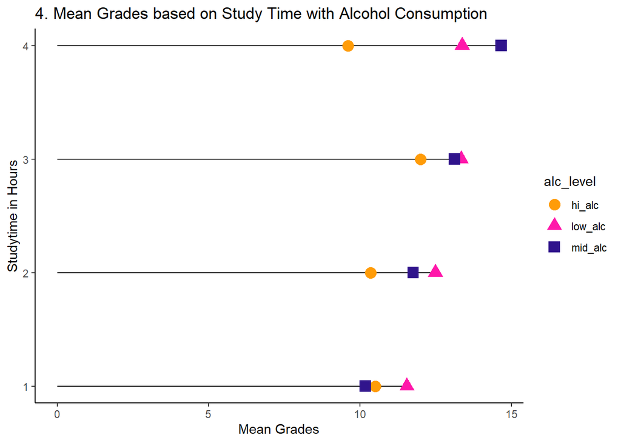

## Results from the Selected Graphs

Activities: From the Activity graph, we can see that whether or not students participates being involved in activities are more likely to get better grades even with the same Study Hours. Except for those who studied 3 hours, the averages of those who choose to participate in activities have higher grades. While this is an average difference between those who participate in activities the difference is not incredible large as on average mean grades remain above 10.

Romance:

From the Romance graph, we can see that whether or not students participates being involved in relationships in highschool are more likely to get better grades even with the same Study Hours. Again, similar to the actives graph except for those who studied 3 hours, the averages of those who weren’t in a romantic relationship had average higher grades for the study time. Again, the gap is not incredibly large as on average mean grades remain above 10.

Failures:

From the Failures graph, we can see that those having 0 failures are significantly more likely to get better grades even with the same number of Study Hours. Those who have 1-2 failures have significantly lower performance levels. Here there is a large gap between those who have failed on a test vs. those who haven’t.

## Conclusion

From these graphs they show that even when you keep Study time consistent there is a relationship that students external actions have with their grades. The four key take aways are

1. perform at least some extracurricular activity
2. Not be in a romantic relationship
3. Avoid any failures
4. have mid or low alcohol consumption

One of the largest impacts on student grades is the presence of a failure. Additionally it seems to be key to avoid drinking hih levels of alcohol consistently which I classified as drinking 7-10 times per week. This makes sense as this consistent alcohol consumption would consistently impair a students daily performance whereas a mid or low level alcohol consumption means that students can catch up on their work or studying.